# Mini_Tutorial_3

Kaden Pickering

3/8/2022

“All work presented is my own. I have not communicated with or worked with anyone else on this exam.”

# Expressing Uncertainty

The goal of this section is to show how some plots, like bar plots for example, are bad visualizations when it comes to expressing variability in data. Some statistics in a sample can obscure data to make it seem like the output is telling a different story than should be told. For this section, I will use the athletesdata.csv file to show how a visualization can hide variability in statistics by comparing athlete salaries from their respective sports and see what sport pays it’s players the most.

```r
library(tidyverse)
athlete_df <- read_csv("data-2/athletesdata.csv")
```

```
## * `` -> ...1
```

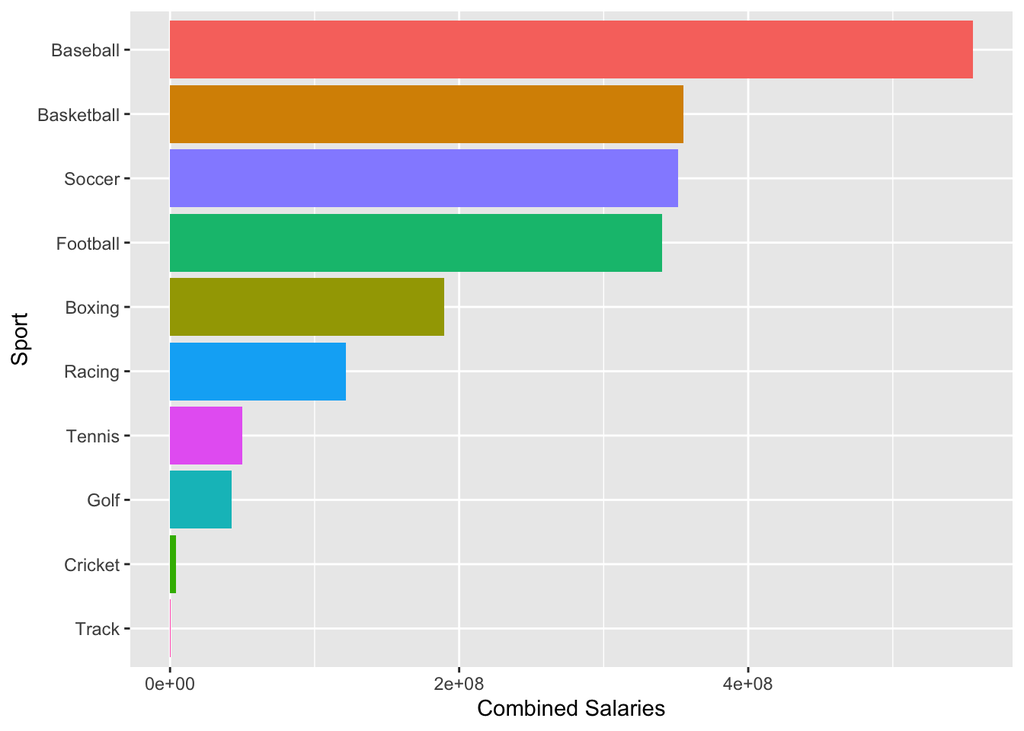

```r
clean_athlete <-
  athlete_df %>%
  group_by(Sport) %>% # get data only for sports
  mutate(ntotal = n()) %>% # count number of stats under each sport
  select(Sport, salary) %>% # new data frame with only columns we are concerned with
  summarise(combined_salary = sum(salary)) # add up all salaries from each sport to get how much is paid to each sport

ggplot(clean_athlete, aes(x = reorder(Sport, +combined_salary), y = combined_salary, fill = Sport)) +
  geom_col() +
  coord_flip() +
  labs(x = "Sport", y = "Combined Salaries") +
  theme(legend.position = "none")
```

From looking at this graph, it looks like baseball is far and away the highest paid sport. While this may be true, there may be some underlying data that skews these results that are not being shown in my graphic. In order to correct that and account for variability, I need to make a graphic that shows averages and standard deviations in order to see the variability in the numbers.

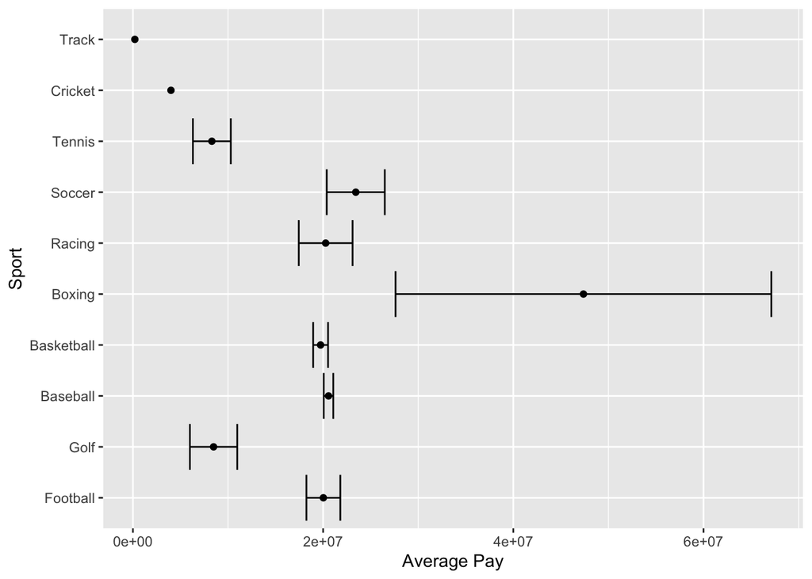

```r
clean2_athlete <- # new data set
  athlete_df %>% # using old data set
  mutate(Sport = fct_inorder(Sport)) %>% # Create sport to incorporate all instances
  group_by(Sport) %>%
  summarise(meanpay = mean(salary), # create mean, sd, and n
            sdpay = sd(salary),
            npay = n()) %>%
  mutate(l_se = meanpay - sdpay / sqrt(npay),
         u_se = meanpay + sdpay / sqrt(npay))

ggplot(data = clean2_athlete, aes(x = Sport, y = meanpay)) + # create a plot that starts with mean
  geom_point() +
  geom_errorbar(aes(ymin = l_se, ymax = u_se)) + # input error bars to show variation in pay
  labs(x = "Sport", y = "Average Pay") + # change the labels
  coord_flip() # flip it sideways so easily readable
```